# IE 582 Final - Kaan Bilgin

Kaan Bilgin

2/6/2021

# **Summary**

# **1.Introduction**

In machine learning, multi-instance learning (MIL) is a variant of supervised learning. Instead of getting a series of individually labeled instances, the learner should receives a set of labeled bags, each containing multiple instances. In the simple case of a binary classification with multiple instances, a bag can be marked as negative if all the instances it contains are negative. Sure On the other hand, a bag is marked as positive if there is at least one instance in it that is positive. Of With a collection of labeled bags, the learner either tries (i) to develop a concept that labels the person Instances correctly or (ii) learn to label the bags without inducing the concept.

The goal is come up with a two alternative bag-level represtations for the given dataset and problem. Problem is whether to predict that new molecules will be musk or non-musk, and what makes this problem a MIL problem is that since bonds can rotate, a single molecule can adopt different shapes more than 1.

We will start with importing libraries and splitting the given data.

# **2.Libraries**

```r
library(milr)
library(data.table)
library(magrittr)
library(dplyr)
library(pipeR)
library(class)
library(caret)
library(mlbench)
library(tidyverse)
library(cluster)
library(factoextra)
library(dendextend)
```

Imported data normalized to handle better and splitted into train and test data.

# **3.Data Import, Handling and Splitting**

```r
# reading data
data = read.table("Musk1.csv", sep = ",")

# backup file
data2 <- data

# custom normalization function
normalize <- function(x) {
return ((x - min(x)) / (max(x) - min(x))) }

# applying normalization
data2.n <- as.data.frame(lapply(data2[,2:168], normalize))

## 75% of the sample size
data_size <- floor((2/3) * nrow(data2.n))

## set the seed to make your partition reproducible
set.seed(123)

# splitting the data as train and test set
data_train_ind <- sample(seq_len(nrow(data2.n)), size = data_size)

train_data <- data2[data_train_ind, ]
test_data  <- data2[-data_train_ind, ]

train.data_labels <- data2[data_train_ind, 1]
test.data_labels  <- data2[-data_train_ind,1]
```

# **4.Approaches**

## **4.1.KNN**

I modeled and optimized a KNN for k value to come up with a better fit. Usually I saw that the using square root of the data size is the k-go parameter but I wanted to obtain the best, so I coded a loop.

### **4.1.1.Model Training and Parameter Tuning**

```r
# training the optimum outcome KNN
i = 1
k.optm = 1


for (i in 1:23){

    knn.mod <- knn(train = train_data, test = test_data, cl = train.data_labels, k = i, prob = TRUE)

    k.optm[i] <- 100 * sum(test.data_labels == knn.mod)/NROW(test.data_labels)

    k=i

    cat(k,'=',k.optm[i],'')}
```

[output not shown]

```r
max_k <- max(k.optm[])

print(max_k)
```

```
## [1] 89.30818
```

I plot the obtained accuracy results before AUC.

### **4.1.2.KNN Results**

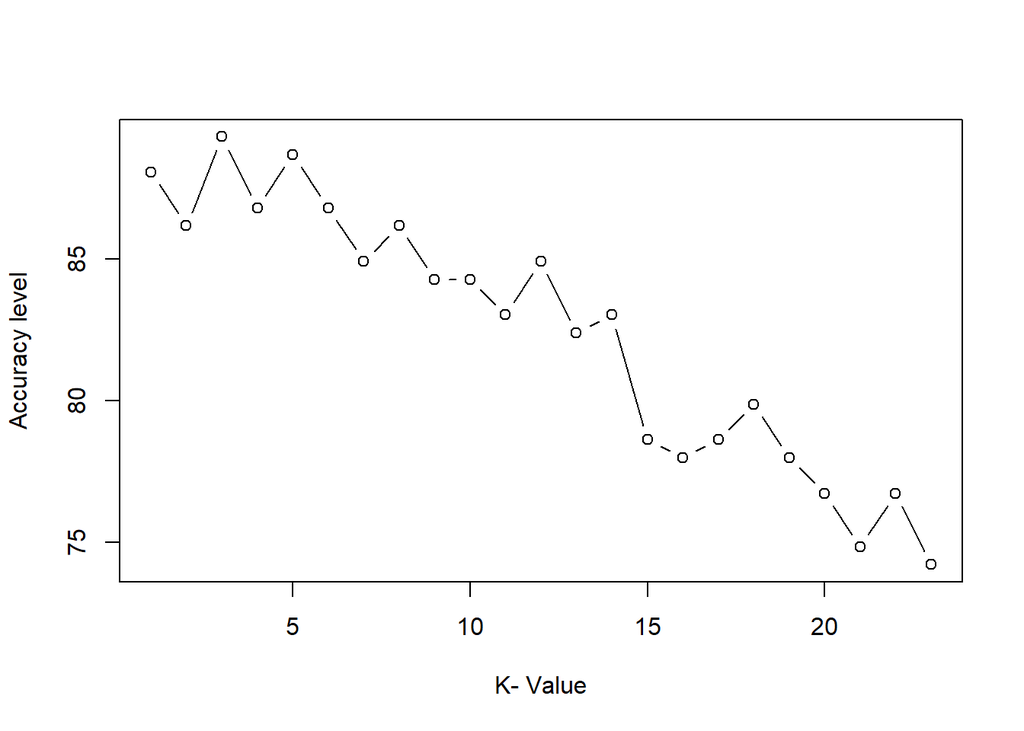

```r
# optimum

plot(k.optm, type="b", xlab="K- Value", ylab="Accuracy level")
```

### **4.1.3.AUC**

```r
# area under curve plot
attributes(knn.mod)$prob
```

```
##   [1] 0.9130435 0.8695652 0.8695652 0.8695652 0.8695652 0.8695652 0.8260870
##   [8] 0.8260870 0.8260870 0.8260870 0.6521739 0.7826087 0.7391304 0.9130435
##  [15] 0.8695652 0.6521739 0.6521739 0.5217391 0.5217391 0.6521739 0.5217391
##  [22] 0.7391304 0.7826087 0.9130435 0.6521739 0.8260870 0.8695652 0.7826087
##  [29] 0.5217391 0.5217391 0.6956522 0.7826087 0.8260870 0.7391304 1.0000000
##  [36] 0.7826087 0.7826087 0.8260870 0.8260870 0.6956522 0.7826087 0.9565217
##  [43] 0.6086957 0.6956522 0.7826087 0.9565217 0.6956522 0.6086957 0.6956522
##  [50] 0.8260870 0.7826087 0.7391304 0.8695652 0.9565217 0.9565217 0.8695652
##  [57] 0.7826087 0.8695652 0.5217391 0.9130435 0.6956522 0.6521739 0.7826087
##  [64] 0.8695652 0.6521739 0.6956522 0.5217391 0.9565217 0.7826087 0.8260870
##  [71] 0.6956522 1.0000000 0.8260870 0.8695652 0.6086957 0.6521739 0.6521739
##  [78] 0.5652174 0.6086957 0.5652174 0.7826087 0.5652174 0.8260870 0.6956522
##  [85] 0.6521739 0.6956522 0.5217391 0.5217391 0.5652174 0.5652174 0.6086957
##  [92] 0.6521739 0.7391304 0.6086957 0.6086957 0.5652174 0.6086957 0.5652174
##  [99] 0.5652174 0.5652174 0.5217391 0.5652174 0.5217391 0.5217391 0.6086957
## [106] 0.5217391 0.6956522 0.7391304 0.5217391 0.5652174 0.6521739 0.5217391
## [113] 0.5652174 0.6956522 0.6521739 0.5652174 0.5217391 0.6086957 0.5652174
## [120] 0.6086957 0.5652174 0.6086957 0.6086957 0.7391304 0.6086957 0.7391304
## [127] 0.5652174 0.7391304 0.7391304 0.8260870 0.6956522 0.9130435 0.6956522
## [134] 0.6086957 0.6521739 0.7826087 0.8260870 0.6956522 0.7826087 0.6956522
## [141] 0.7391304 0.9130435 0.8260870 0.6956522 0.5217391 0.5217391 0.5652174
## [148] 0.6956522 0.6956522 0.6956522 0.5652174 0.7391304 0.5652174 0.8260870
## [155] 0.8260870 0.6956522 1.0000000 0.6956522 0.5652174
```

```r
library(pROC)

roc(test_data$V1, attributes(knn.mod)$prob)
```

```
##
## Call:
## roc.default(response = test_data$V1, predictor = attributes(knn.mod)$prob)
##
## Data: attributes(knn.mod)$prob in 85 controls (test_data$V1 0) < 74 cases (test_data$V1 1).
## Area under the curve: 0.7717
```

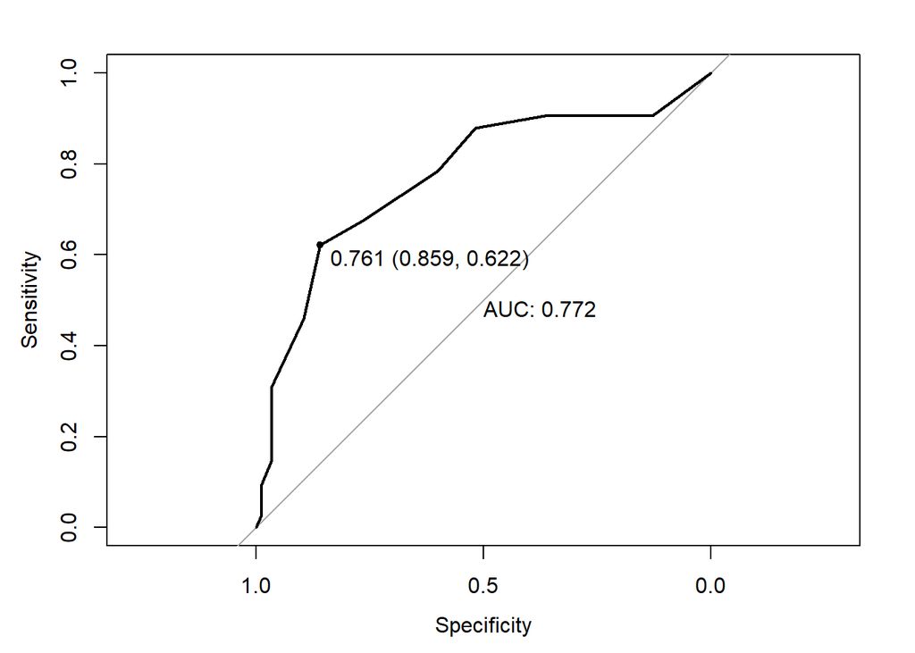

```r
plot(roc(test_data$V1, attributes(knn.mod)$prob),
     print.thres = T,
     print.auc = T)
```

Overall, a good curve. Adequate.

## **4.2.Hierarchical Clustering**

After some comment on discussion board and doing KNN, I wanted to see if clustering works for this problem, so I searched and found this paper [Multi-instance clustering with applications to multi-instance prediction, Min-Ling Zhang, Zhi-Hua Zhou](https://www.researchgate.net/publication/220204694_Multi-instance_clustering_with_applications_to_multi-instance_prediction) where they apply multi instance clustering at multi instance problems. I wanted to apply hierarchical clustering to obtain a good fit since this also deals with dissimilarities like distance handling at KNN.

### **4.2.1.Agglomerative Hierarchical Clustering, HCLust**

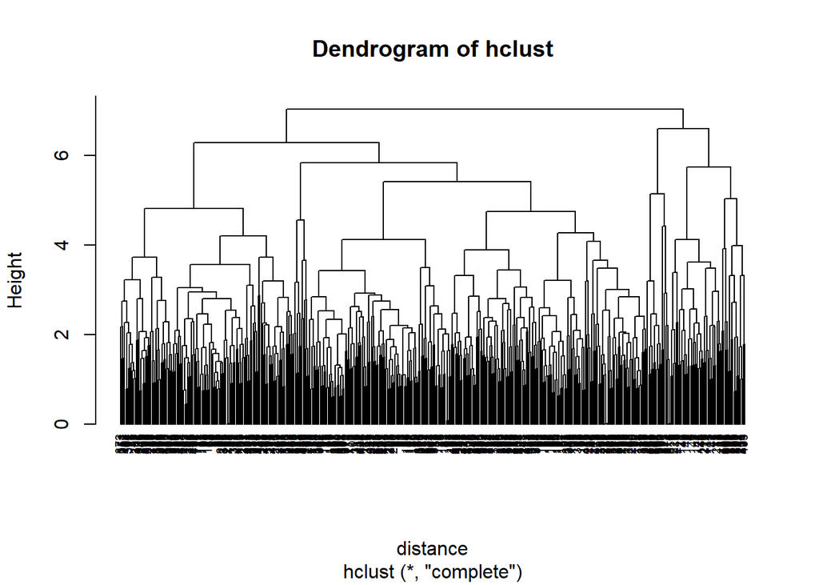

```r
# dissimilarity calculating
distance <- dist(data2.n, method = "euclidean")

# hierarchical clustering
hc1 <- hclust(distance, method = "complete")

# dendogram plotting
plot(hc1, cex = 0.6, hang = -1, main = "Dendrogram of hclust")
```